# Vaccination

Sylvia Liu

01/05/2022

```r
library(tidyverse)
```

```r
library(readxl)
library(tibble)
library(ggplot2)
library(ggthemes)
library(maps)
library(plotly) # Interactive data visualizations
library(viridis) # Color gradients
library(lubridate)
library(randomForest)
library(ranger)       # a faster implementation of randomForest
library(caret)        # performe many machine learning models
library(broom)  # try: `install.packages("backports")` if diretly installing broom gives an error
```

## Reading data

```r
covid_data <- read.csv("owid-covid-data-160222.csv")
covid_data$date <- as.Date(covid_data$date, format = "%d/%m/%y")
#head(covid_data)
```

## Vaccinations progress - Vaccine Roll-Out Index (VRI) values for the countries

(Reference: https://www.mdpi.com/2076-393X/10/2/194/htm)

> **Estimate Vaccine Uptakes Rates r* for Countries** “The logistic growth model was used to estimate the vaccination uptake rate. In the logistic model, the cumulative number of doses administered c(t) satisfies the following equation:
> $$c(t) = \frac{K}{1+a\cdot{e}^{-r\cdot t}}$$
> ,”_ where K is the total vaccinations administered at the end of the date recorded, r is the vaccination uptake rate(i.e. speed), and $\frac{K}{1+a} = c(0)$ is the initial number of doses given.

```r
## TODO: Add a condition check or restrict the country to be passed (avoid error from missing values)
## TODO: Add constraints on argument format? Adding more conditional checks?

set.seed(3888)

### Estimate Vaccine Uptakes Rates r* for Countries
# Step 1: A function that returns the logistic model used for estimating r*

estimate_uptake_rate <- function(country) {

  data <- covid_data %>% filter(location == country) %>% filter(!is.na(total_vaccinations) & total_vaccinations != 0) %>% arrange(date)
  K <- data %>% select(total_vaccinations) %>% slice_tail() %>% pull()

  ## Calculate t by ranking the date
  data$t <- rank(data$date)

  ## Taking the model to get fitted
  x <- data$t-1
  y <- data$total_vaccinations
  m <- nls( y ~ (K / (1 + a*exp(-r*x))), start = list(a=0.01,r=0.01),control=nls.control(maxiter=200)) #a,r are the coefficients

  return(list(model=m))

}

# Example
res_nls  = estimate_uptake_rate("Japan")
summary(res_nls$m)
```

```
##
## Formula: y ~ (K/(1 + a * exp(-r * x)))
##
## Parameters:
##    Estimate Std. Error t value Pr(>|t|)
## a 2.128e+02  7.156e+00   29.74   <2e-16 ***
## r 3.495e-02  2.147e-04  162.78   <2e-16 ***
## ---
## Signif. codes:  0 '***' 0.001 '**' 0.01 '*' 0.05 '.' 0.1 ' ' 1
##
## Residual standard error: 3240000 on 265 degrees of freedom
##
## Number of iterations to convergence: 28
## Achieved convergence tolerance: 7.859e-07
```

**Evaluation of the metric on est.r**

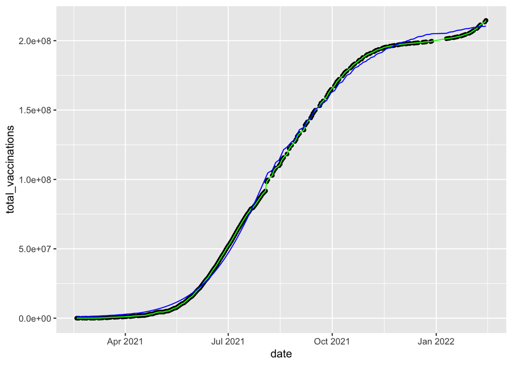

```r
## Step2: Another function for evaluating the logistic model we created for the estimate r (r*),
## including fitted plots, correlation values and residual values
evaluate_est_r <- function(country, m) {

  data <- covid_data %>%
    filter(location == country) %>%
    filter(!is.na(total_vaccinations) & total_vaccinations != 0) %>%
    arrange(date)

  # goodness of fit
  corr = round(cor(data$total_vaccinations, predict(m)),4)

  # minimized residual value
  resid = round(sum(resid(m)^2),4)

  # Plot fitted values vs true values
  p <- ggplot(data, aes(x = date, y = total_vaccinations)) +
  geom_point()+
  geom_line(aes(x = date, y = total_vaccinations), color="green")+
  geom_line(aes(x=date,y=predict(m)), color="blue")

  return(list(plot=p,corr=corr,resid=resid))
}

# Example:
eval_res  = evaluate_est_r("Japan",res_nls$m)
eval_res$plot
```

```r
paste("goodness of fit:",eval_res$corr)
```

```
## [1] "goodness of fit: 0.9992"
```

```r
paste("minimized residual value",eval_res$resid)
```

```
## [1] "minimized residual value 2781321208357791"
```

> Define and Calculate Vaccine Roll-Out Index (VRI) “The Vaccine Roll-out Index (VRI) for a country was defined as follows:
> $$VRI=r\cdot \frac{d}{N}$$
> ,” where r is the vaccination uptake rate as defined in the previous section, d is the total vaccinations, and N is the population.

**VRI was used as an index to compare the overall vaccination progression among different countries, as it reflects both the speed and the density/extend.**

```r
# Step 3 calculate VRI using: est_rate * d/N
## TODO: adding constraits on argument format? Adding more conditional checks?

cal_VRI <- function(country, est_rate, spec_date) {

  data <- covid_data %>%  filter(location == country) %>% filter(!is.na(total_vaccinations) & total_vaccinations != 0) %>% arrange(date) %>% filter(date <= as.Date(spec_date) )
  d <- data %>% select(total_vaccinations) %>% slice_tail() %>% pull()
  N <- data %>% filter(!is.na(population)) %>% select(population) %>% slice_tail() %>% pull()
  VRI = est_rate * d/N
  return(vri=VRI)

}
```

> Comment: The function could be adjusted accordingly for the shiny app, for example: - Changing the argument to pass in the model *m* instead of *est. r* value - Changing a single end date to a range of dates.

*Side Note: Use it in a for loop to calculate the VRI for the countries you want* ### Calculate `est.r` and `VRI` for all countries with no null values in `toal_vaccinations` column within the input date

```r
# Selecting countries with enough vaccination data
# Set a baseline that the country we selected should has at least 180 days(i.e. 6 months) recorded for the value of vaccinations

valid_countries_df <- covid_data %>%
    filter(!is.na(total_vaccinations) & !is.na(population)) %>%
    group_by(iso_code,location) %>%
    summarise(count=n())  %>%
    filter(count >= 180 & !grepl("^OWID.", iso_code))  %>% # Remove continent and income groups
    ungroup()
selected_countries <- valid_countries_df$location
# selected_countries

# Calculate VRI, giving end date = "2022-02-16" (or any valid date)
results_r <- c(NA,NA) #c("Country name", est_r)
for (i in selected_countries) {
  res_model <- estimate_uptake_rate(i)$model
  results_r <- rbind(results_r,c(i,round(summary(res_model)$parameters[2],4)))
}
results_r <- results_r[-1,]
colnames(results_r) <- c("Location","Est.r")
results_r <- data.frame(results_r)
results_r$Est.r <- as.double(results_r$Est.r)
head(results_r)
```

```
##                 Location  Est.r
## X                  Aruba 0.0248
## X.1              Albania 0.0201
## X.2 United Arab Emirates 0.0153
## X.3            Argentina 0.0175
## X.4            Australia 0.0195
## X.5           Azerbaijan 0.0198
```

```r
results_vri <- c(NA,NA) #c("Country name", VRI)
cutoff_date = "2021-08-01"

for (i in c(1:nrow(results_r))) {
  vri = cal_VRI(results_r$Location[i],results_r$Est.r[i], cutoff_date)
  results_vri <- rbind(results_vri,c(results_r$Location[i],round(vri,4)))
}
results_vri <- results_vri[-1,]
colnames(results_vri) <- c("Location","VRI")
results_vri <- data.frame(results_vri)
results_r$VRI <- as.double(results_vri$VRI)
head(results_vri)
```

```
##                 Location    VRI
## X                  Aruba  0.032
## X.1              Albania 0.0084
## X.2 United Arab Emirates 0.0257
## X.3            Argentina 0.0123
## X.4            Australia 0.0094
## X.5           Azerbaijan 0.0098
```

### The association between vaccination uptake rate and social-economic factors

#### Merging datasets

```r
gov_trust <- read_csv("share-who-trust-government.csv")
#gov_trust

corruption <- read_xlsx("CPI2020_GlobalTablesTS_210125.xlsx", sheet=1,skip=2)
corruption <- corruption %>% filter(Country %in% selected_countries) %>% select (c("ISO3", "CPI score 2020"))
#corruption

happiness <- read_csv("happiness-cantril-ladder.csv")
happiness <- happiness %>% group_by(Code) %>%
  arrange(Year) %>%
  filter(!is.na(`Life satisfaction in Cantril Ladder (World Happiness Report 2021)`)) %>%
  summarise(satisfaction=last(`Life satisfaction in Cantril Ladder (World Happiness Report 2021)`))

covid_grouped <- covid_data %>% group_by(iso_code) %>%
  arrange(date) %>%
  #filter(!is.na(population_density),median_age,aged_65_older,aged_70_older,gdp_per_capita,extreme_poverty,stringency_index,human_development_index,life_expectancy))) %>%
  slice_tail()

joint_data <- merge(covid_grouped,gov_trust, by.x=c("iso_code"), by.y=c("Code")) %>% filter(location %in% selected_countries)
#joint_data
joint_data <- merge(joint_data,corruption,  by.x=c("iso_code"), by.y=c("ISO3"))

joint_data <- merge(joint_data,happiness,  by.x=c("iso_code"), by.y=c("Code"))
head(joint_data)
```

[output not shown]

[output cut: 146 more lines]

Merge joint covid data with VRI.

```r
vri_covid_cov_data <- merge(joint_data,results_vri,by.x=c("location"), by.y=c("Location"))
vri_covid_cov_data$VRI <- as.double(vri_covid_cov_data$VRI)
head(vri_covid_cov_data)
```

[output not shown]

[output cut: 153 more lines]

#### Selecting Covariates

##### Demographic factors (scatter plots)

Variables: `population_density`, age(`aged_65_older`/`aged_70_older`), `gdp_per_capita`,

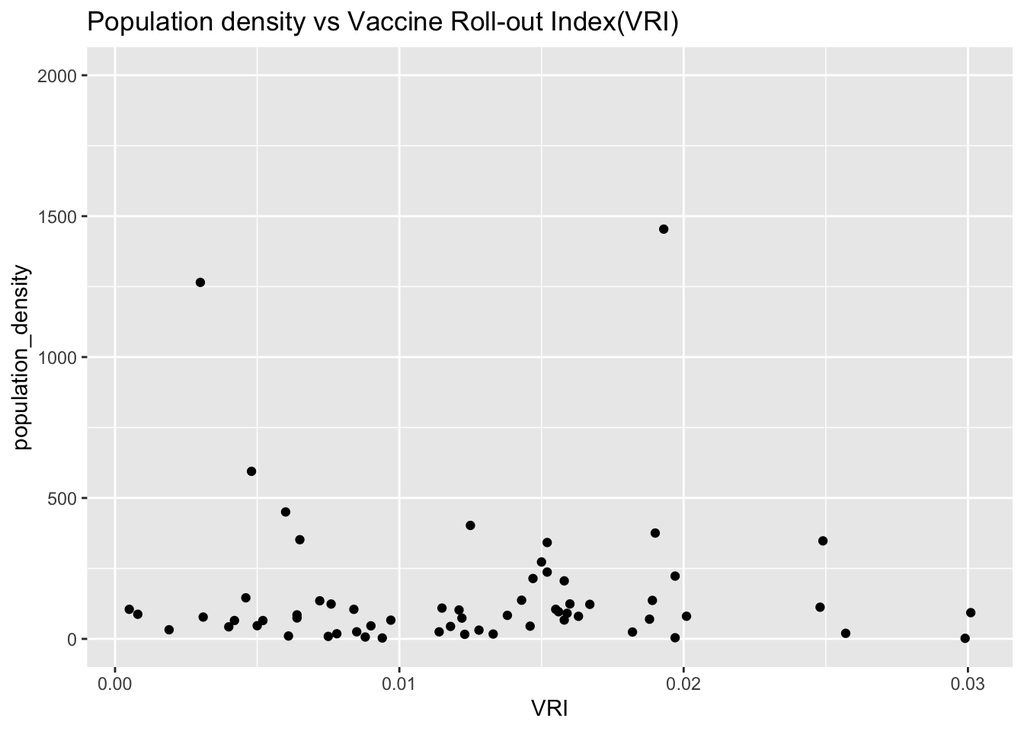

```r
# Basic scatter plot
df <- vri_covid_cov_data %>% filter(VRI > -0.32)
ggplot(df, aes(x=VRI, y=population_density)) + geom_point() + ggtitle("Population density vs Vaccine Roll-out Index(VRI)") + ylim(c(0,2000))
```

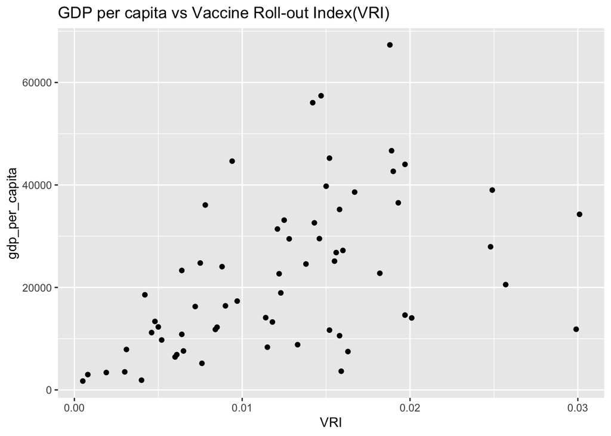

```r
ggplot(df, aes(x=VRI, y=gdp_per_capita)) + geom_point() + ggtitle("GDP per capita vs Vaccine Roll-out Index(VRI)")
```

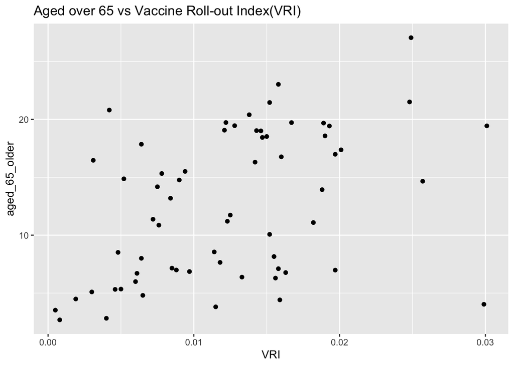

```r
ggplot(df, aes(x=VRI, y=aged_65_older)) + geom_point() + ggtitle("Aged over 65 vs Vaccine Roll-out Index(VRI)")
```

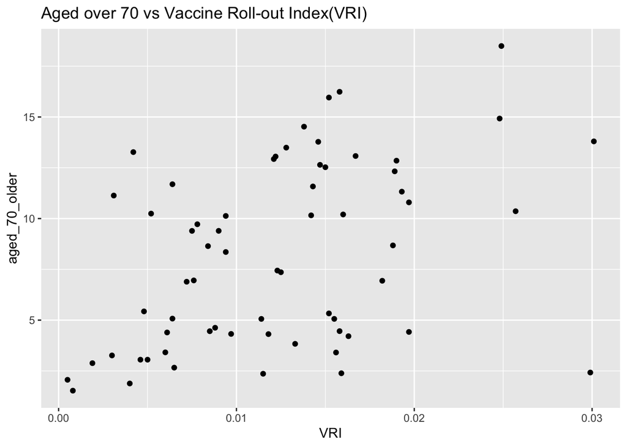

```r
ggplot(df, aes(x=VRI, y=aged_70_older)) + geom_point() + ggtitle("Aged over 70 vs Vaccine Roll-out Index(VRI)")
```

##### Social and Economic Variables: Stringency(`stringency_index`), trust(`share_who _trust_government`), corruption(`CPI score 2020`), happiness(`satisfaction`), `extreme_poverty`, `human_development_index`, `life_expectancy`.

Questions: Healthcare?(In total or in details) Education? More economic variables? AND NO SOCIAL MEDIA TRUST DATA IS FOUND

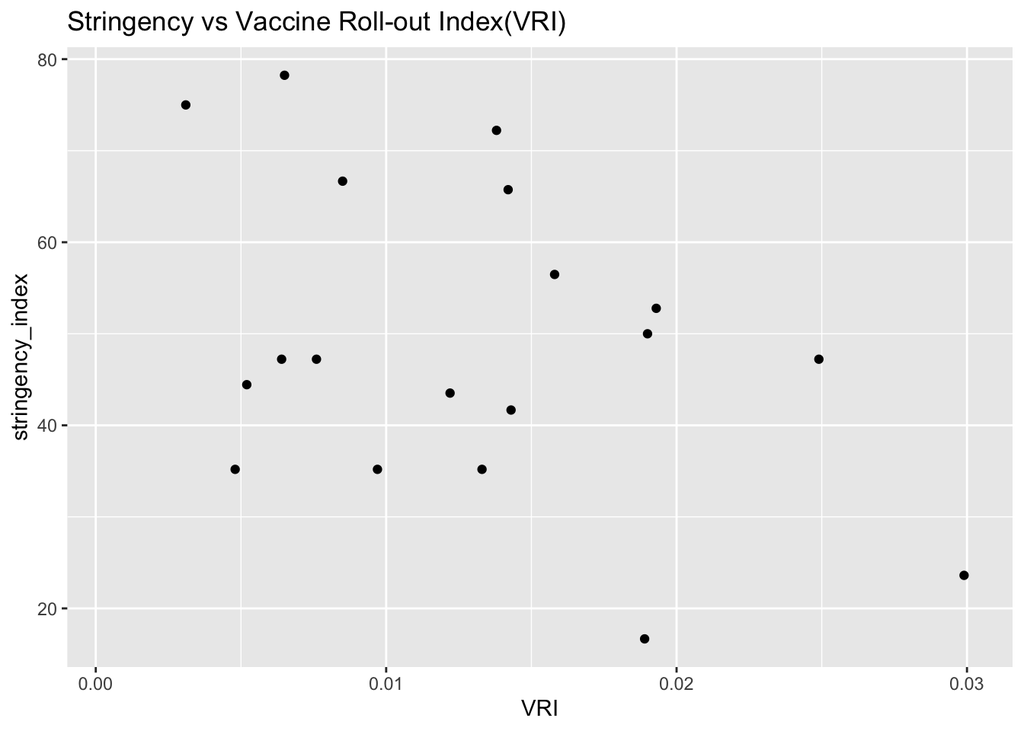

```r
ggplot(df, aes(x=VRI, y= stringency_index)) + geom_point() + ggtitle("Stringency vs Vaccine Roll-out Index(VRI)")
```

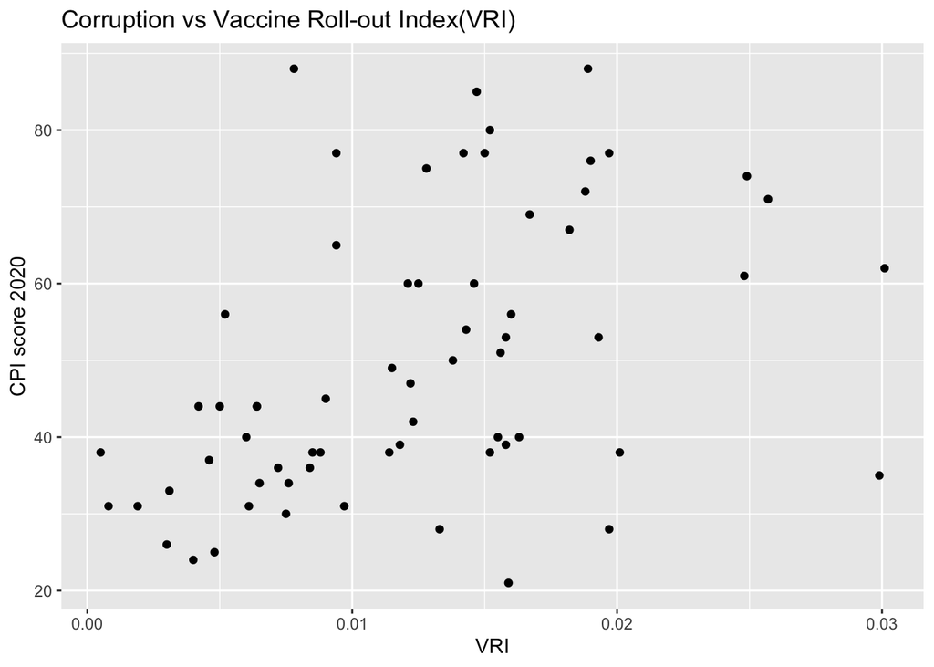

```r
ggplot(df, aes(x=VRI, y=`CPI score 2020`)) + geom_point() + ggtitle("Corruption vs Vaccine Roll-out Index(VRI)")
```

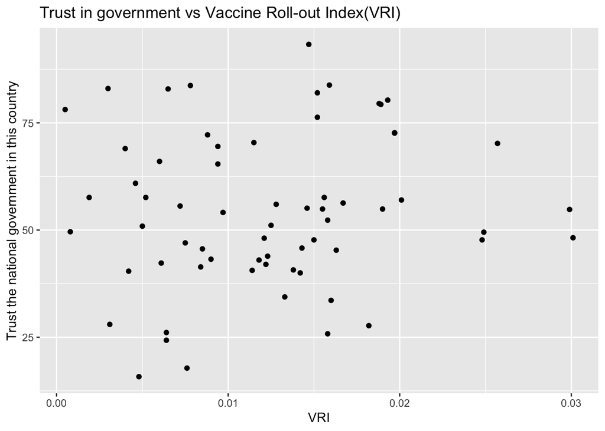

```r
ggplot(df, aes(x=VRI, y= `Trust the national government in this country`)) + geom_point() + ggtitle("Trust in government vs Vaccine Roll-out Index(VRI)")
```

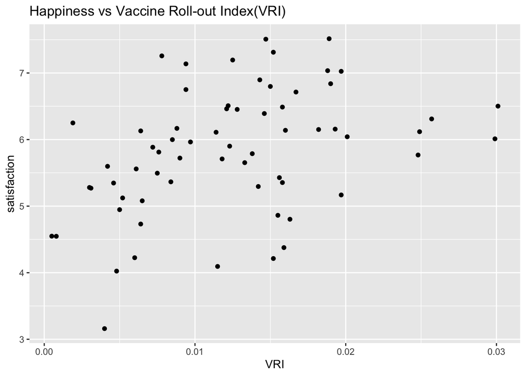

```r
ggplot(df, aes(x=VRI, y= satisfaction)) + geom_point() + ggtitle("Happiness vs Vaccine Roll-out Index(VRI)")
```

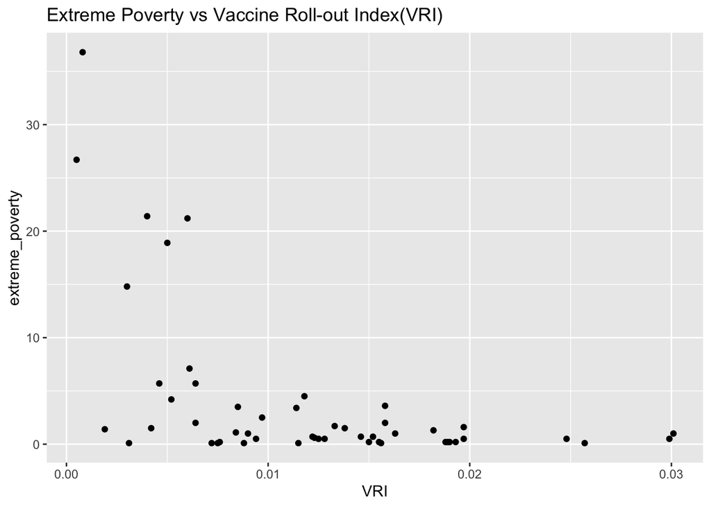

```r
ggplot(df, aes(x=VRI, y= extreme_poverty)) + geom_point() + ggtitle("Extreme Poverty vs Vaccine Roll-out Index(VRI)")
```

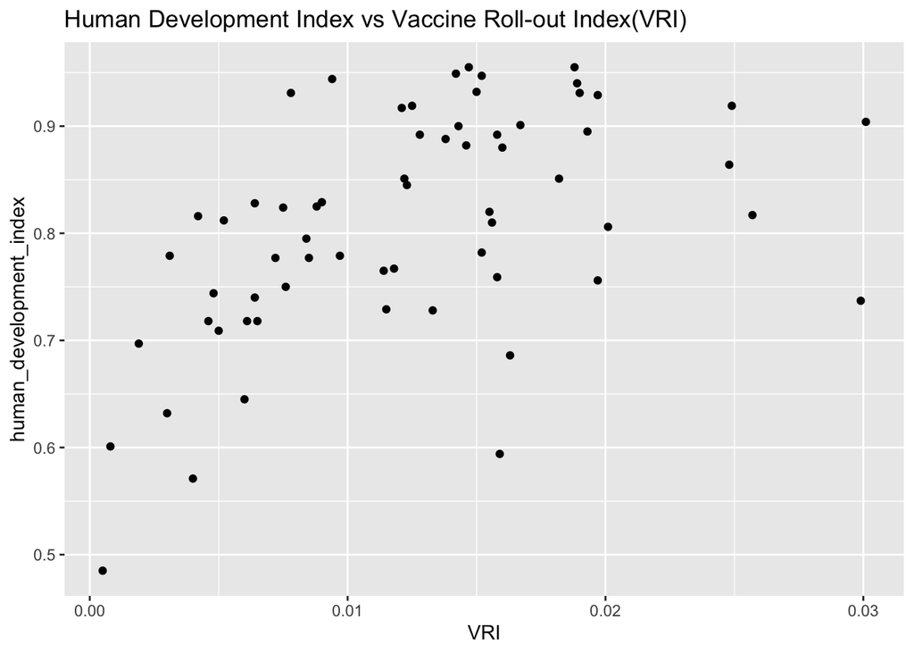

```r
ggplot(df, aes(x=VRI, y= human_development_index)) + geom_point() + ggtitle("Human Development Index vs Vaccine Roll-out Index(VRI)")
```

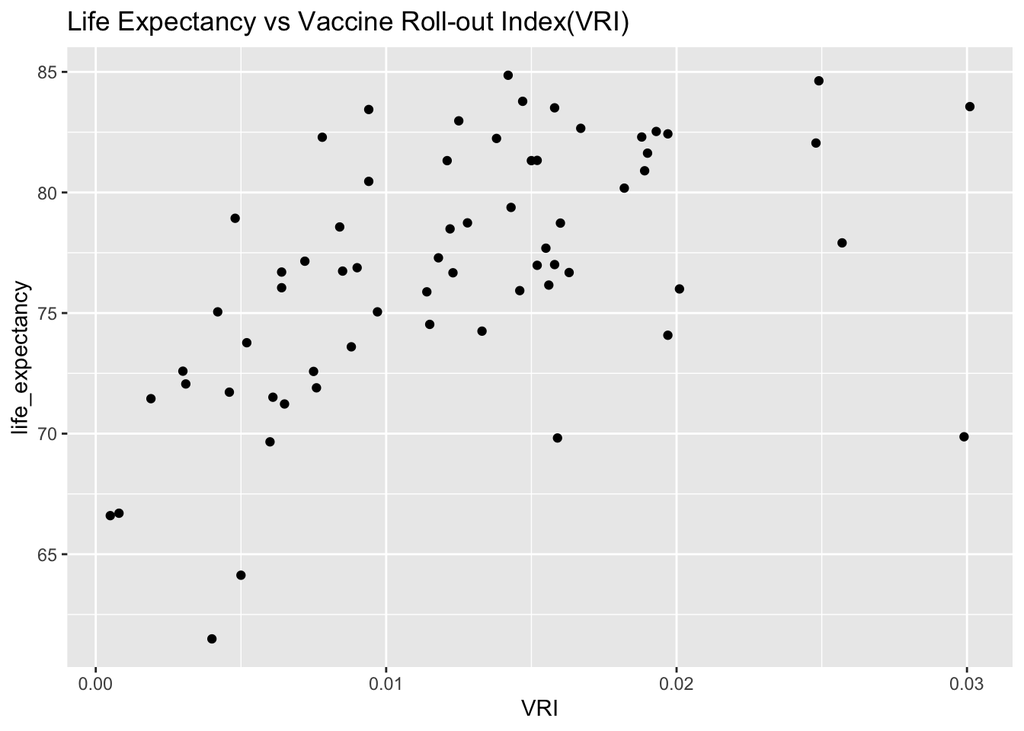

```r
ggplot(df, aes(x=VRI, y= life_expectancy)) + geom_point() + ggtitle("Life Expectancy vs Vaccine Roll-out Index(VRI)")
```

#### Random Forest-Based Regression Analysis of the Association between Covariates and VRI

##### >TO DO: Need further check on parameter setting in grid search (add corss validation)

##### >TO DO: Model Validation

As we are interested in the association between VRI and those factors(i.e. the random forest aggressor acts as a selector ), we will include all data as the training set.

To tune the hyperparameters in the random forest model, we perform a grid search with ranger, which is a a fast implementation of random forests. (Breiman 2001) (https://cran.r-project.org/web/packages/ranger/ranger.pdf)

```r
# hyperparameter grid search
grid_param <- expand.grid(
  mytry  = seq(2, 10, by = 2),
  #node_size  = seq(3, 9, by = 1),
  # maxnodes =
  sampe_size = c(0.55, 0.6, 0.65, 0.7,0.75, 0.8),
  OOB_MSE   = 0
)

# total number of combinations of hyper-parameters
nrow(grid_param)
```

```
## [1] 30
```

```r
# Reference: https://uc-r.github.io/random_forests
# make ranger compatible names
names(df) <- make.names(names(df), allow_ = FALSE)

df_forRF <- df %>% filter(!is.na(population.density)&!is.na(gdp.per.capita)&
  !is.na(aged.65.older)&!is.na(stringency.index)&!is.na(extreme.poverty)&!is.na(human.development.index))

for(i in 1:nrow(grid_param)) {

  # TODO: ADD 10-fold cross-validation


  # train model
  model <- ranger(
    seed            = 3888,
    formula         = VRI ~ population.density+gdp.per.capita+aged.65.older+
                        stringency.index+CPI.score.2020+
                        Trust.the.national.government.in.this.country+
                        satisfaction + extreme.poverty +
                        human.development.index +life.expectancy,
    data            = df_forRF,
    num.trees       = 500,
    sample.fraction = grid_param$sampe_size[i],
        min.node.size   = grid_param$node_size[i],
    importance      = "permutation"
    #trControl = train_control
  )

  # add OOB error to grid
  grid_param$OOB_MSE[i] <- sqrt(model$prediction.error)
}

grid_param %>%
  arrange(OOB_MSE) %>%
  head(10)
```

```
##    mytry sampe_size     OOB_MSE
## 1      2       0.80 0.006939807
## 2      4       0.80 0.006939807
## 3      6       0.80 0.006939807
## 4      8       0.80 0.006939807
## 5     10       0.80 0.006939807
## 6      2       0.65 0.007068364
## 7      4       0.65 0.007068364
## 8      6       0.65 0.007068364
## 9      8       0.65 0.007068364
## 10    10       0.65 0.007068364
```

```r
grid_param[which.min(grid_param$OOB_MSE),]
```

```
##    mytry sampe_size     OOB_MSE
## 26     2        0.8 0.006939807
```

```r
OOB_RMSE <- vector(mode = "numeric", length = 100)

for(i in seq_along(OOB_RMSE)) {

  optimal_ranger <- ranger(
    formula         = VRI ~ population.density+gdp.per.capita+aged.65.older+
                        stringency.index+CPI.score.2020+
                        Trust.the.national.government.in.this.country+
                        satisfaction + extreme.poverty +
                        human.development.index +life.expectancy,
    data            = df_forRF,
    num.trees       = 500,
    mtry            = 2, # the number of variables to randomly samples at each split
    min.node.size   = 5, #minimal number
    sample.fraction = 0.8,
    importance      = "permutation"
  )

  OOB_RMSE[i] <- sqrt(optimal_ranger$prediction.error)
}
```

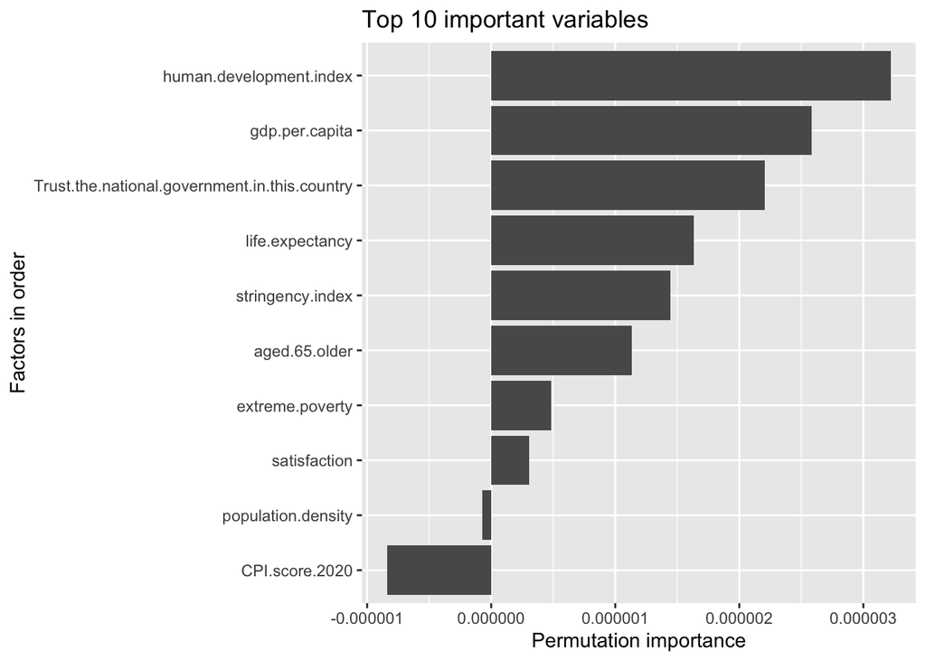

```r
options(scipen=999)
optimal_ranger$variable.importance %>%
  tidy() %>%
  dplyr::arrange(desc(x)) %>%
  dplyr::top_n(10) %>%
  ggplot(aes(reorder(names, x), x)) +
  geom_col() +
  coord_flip() +
  ggtitle("Top 10 important variables") +
  xlab("Factors in order") +
  ylab("Permutation importance")
```